# RClub_Assignment03

Xiaoyan Yue

4/24/2017

# Load the packages

```r
library(tidyverse)
```

```r
library(ggplot2)
theme_set(theme_grey(12))
```

# Practise on mpg

```r
mpg
```

```
## # A tibble: 234 × 11
##    manufacturer      model displ  year   cyl      trans   drv   cty   hwy
##           <chr>      <chr> <dbl> <int> <int>      <chr> <chr> <int> <int>
## 1          audi         a4   1.8  1999     4   auto(l5)     f    18    29
## 2          audi         a4   1.8  1999     4 manual(m5)     f    21    29
## 3          audi         a4   2.0  2008     4 manual(m6)     f    20    31
## 4          audi         a4   2.0  2008     4   auto(av)     f    21    30
## 5          audi         a4   2.8  1999     6   auto(l5)     f    16    26
## 6          audi         a4   2.8  1999     6 manual(m5)     f    18    26
## 7          audi         a4   3.1  2008     6   auto(av)     f    18    27
## 8          audi a4 quattro   1.8  1999     4 manual(m5)     4    18    26
## 9          audi a4 quattro   1.8  1999     4   auto(l5)     4    16    25
## 10         audi a4 quattro   2.0  2008     4 manual(m6)     4    20    28
## # ... with 224 more rows, and 2 more variables: fl <chr>, class <chr>
```

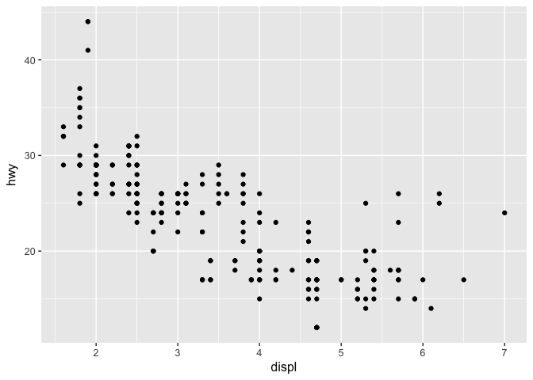

```r
ggplot(data = mpg) +
  geom_point(mapping = aes(x = displ, y = hwy))
```

# Practise 3.2.4

## Run ggplot(data = mpg) what do you see?

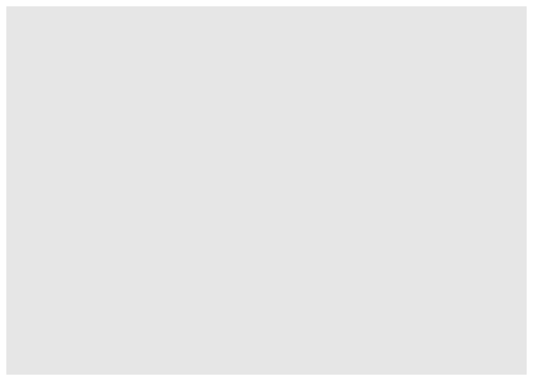

```r
ggplot(data = mpg)#nothing
```

## How many rows are in mtcars? How many columns?

```r
dim(mtcars)
```

```
## [1] 32 11
```

## What does the drv variable describe? Read the help for ?mpg to find out.

```r
?mpg
#f = front-wheel drive, r = rear wheel drive, 4 = 4wd
```

## Make a scatterplot of hwy vs cyl.

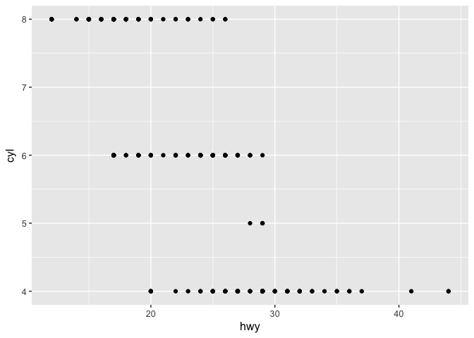

```r
ggplot(data = mpg) + geom_point(mapping = aes(x = hwy, y = cyl))
```

## What happens if you make a scatterplot of class vs drv. Why is the plot not useful?

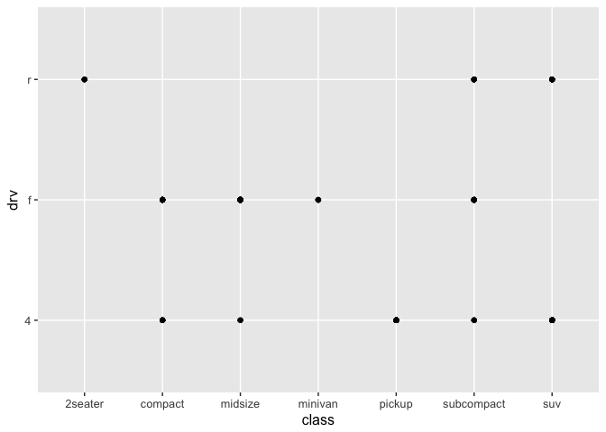

```r
ggplot(data = mpg) + geom_point(mapping = aes(x = class, y = drv))#it's not visualized, no meaningful
```

# practise for Aesthetic mapping

## by color

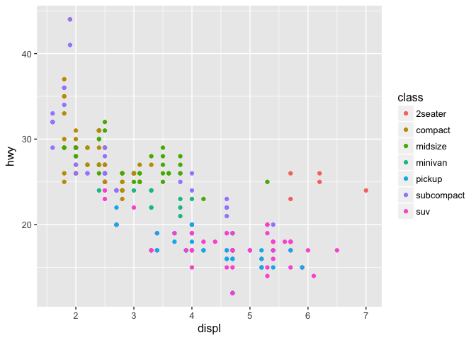

```r
ggplot(data = mpg) +
  geom_point(mapping = aes(x = displ, y = hwy, color = class))
```

## by size

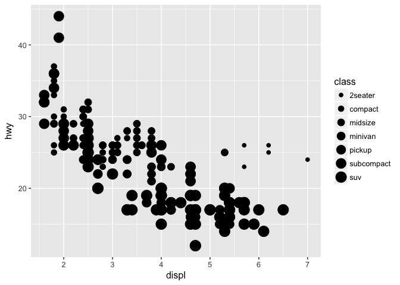

```r
ggplot(data = mpg) +
  geom_point(mapping = aes(x = displ, y = hwy, size = class))
```

## by alpha aesthetic

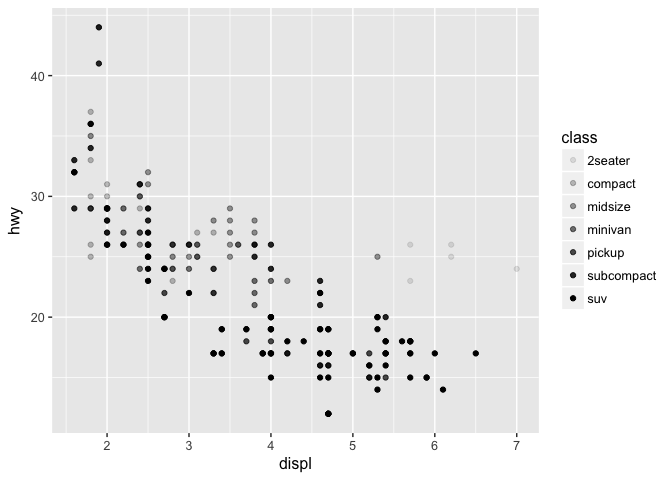

```r
ggplot(data = mpg) +
  geom_point(mapping = aes(x = displ, y = hwy, alpha = class))
```

## by shape aesthetic

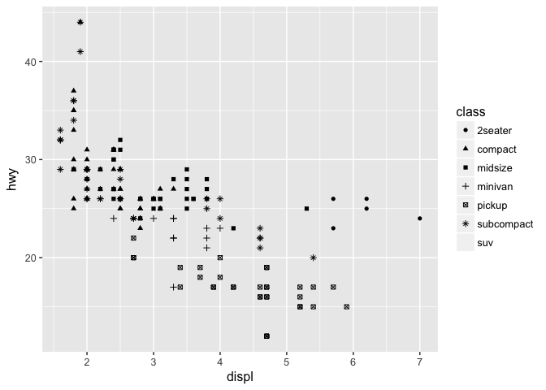

```r
ggplot(data = mpg) +
  geom_point(mapping = aes(x = displ, y = hwy, shape = class))
```

## change the color for the basic aesthetic

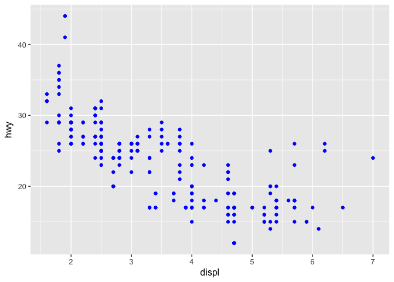

```r
ggplot(data = mpg) +
  geom_point(mapping = aes(x = displ, y = hwy), color = "blue")
```

# practise in 3.3.1

## What’s gone wrong with this code? Why are the points not blue?

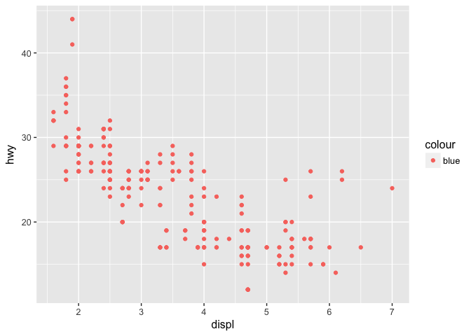

```r
ggplot(data = mpg) +
  geom_point(mapping = aes(x = displ, y = hwy, color = "blue"))
```

```r
#the color need to go outside of aes(), if I want to change the color of the point
```

## Which variables in mpg are categorical? Which variables are continuous? (Hint: type ?mpg to read the documentation for the dataset). How can you see this information when you run mpg?

```r
?mpg
mpg
```

```
## # A tibble: 234 × 11
##    manufacturer      model displ  year   cyl      trans   drv   cty   hwy
##           <chr>      <chr> <dbl> <int> <int>      <chr> <chr> <int> <int>
## 1          audi         a4   1.8  1999     4   auto(l5)     f    18    29
## 2          audi         a4   1.8  1999     4 manual(m5)     f    21    29
## 3          audi         a4   2.0  2008     4 manual(m6)     f    20    31
## 4          audi         a4   2.0  2008     4   auto(av)     f    21    30
## 5          audi         a4   2.8  1999     6   auto(l5)     f    16    26
## 6          audi         a4   2.8  1999     6 manual(m5)     f    18    26
## 7          audi         a4   3.1  2008     6   auto(av)     f    18    27
## 8          audi a4 quattro   1.8  1999     4 manual(m5)     4    18    26
## 9          audi a4 quattro   1.8  1999     4   auto(l5)     4    16    25
## 10         audi a4 quattro   2.0  2008     4 manual(m6)     4    20    28
## # ... with 224 more rows, and 2 more variables: fl <chr>, class <chr>
```

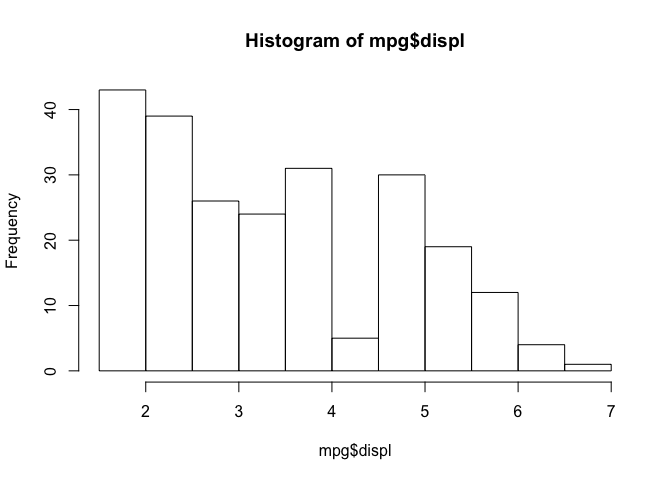

```r
##"manufacturer","model","trans","drv", "fl", and "class" are categorials
##"displ","year","cyl", "cty", and "hwy" are continuous

##let test by plot
hist(mpg$displ)
```

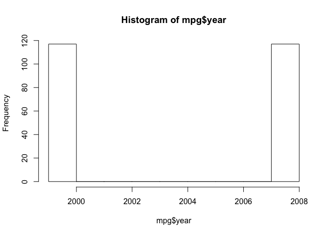

```r
hist(mpg$year)
```

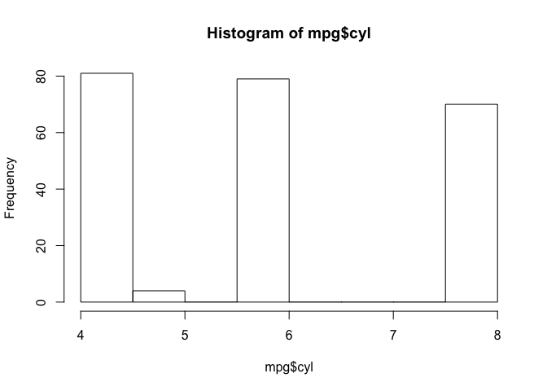

```r
hist(mpg$cyl)
```

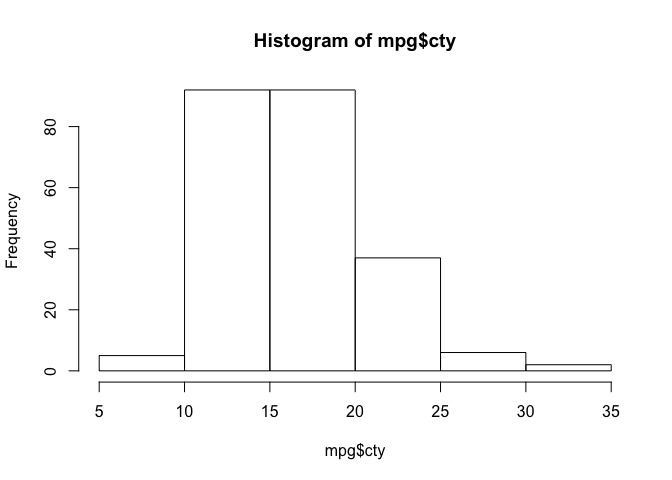

```r
hist(mpg$cty)#normal distribution
```

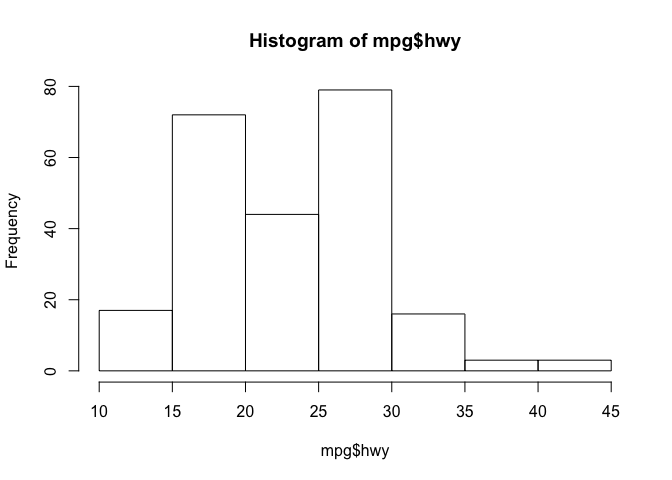

```r
hist(mpg$hwy)#normal distribution
```

## Map a continuous variable to color, size, and shape. How do these aesthetics behave differently for categorical vs. continuous variables?

### color

```r
mpg
```

```
## # A tibble: 234 × 11
##    manufacturer      model displ  year   cyl      trans   drv   cty   hwy
##           <chr>      <chr> <dbl> <int> <int>      <chr> <chr> <int> <int>
## 1          audi         a4   1.8  1999     4   auto(l5)     f    18    29
## 2          audi         a4   1.8  1999     4 manual(m5)     f    21    29
## 3          audi         a4   2.0  2008     4 manual(m6)     f    20    31
## 4          audi         a4   2.0  2008     4   auto(av)     f    21    30
## 5          audi         a4   2.8  1999     6   auto(l5)     f    16    26
## 6          audi         a4   2.8  1999     6 manual(m5)     f    18    26
## 7          audi         a4   3.1  2008     6   auto(av)     f    18    27
## 8          audi a4 quattro   1.8  1999     4 manual(m5)     4    18    26
## 9          audi a4 quattro   1.8  1999     4   auto(l5)     4    16    25
## 10         audi a4 quattro   2.0  2008     4 manual(m6)     4    20    28
## # ... with 224 more rows, and 2 more variables: fl <chr>, class <chr>
```

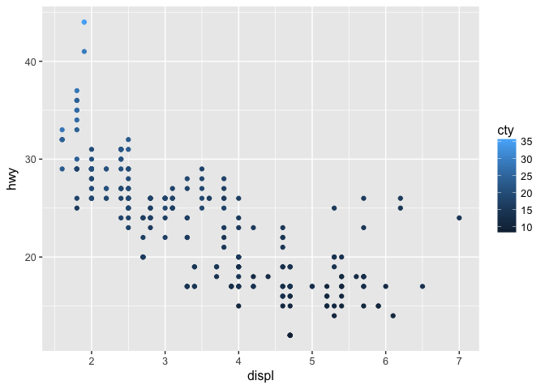

```r
ggplot(data = mpg) +
  geom_point(mapping = aes(x = displ, y = hwy, color = cty))
```

```r
#the colors are also continuous, so it is hard to tell the difference between different continuous variables
```

### size

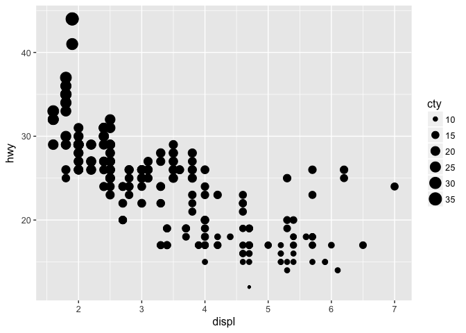

```r
ggplot(data = mpg) +
  geom_point(mapping = aes(x = displ, y = hwy, size = cty))
```

### shape

```r
#mpg
#ggplot(data = mpg) +
  #geom_point(mapping = aes(x = displ, y = hwy, shape = class))
#A continuous variable can not be mapped to shape
```

## What happens if you map the same variable to multiple aesthetics?

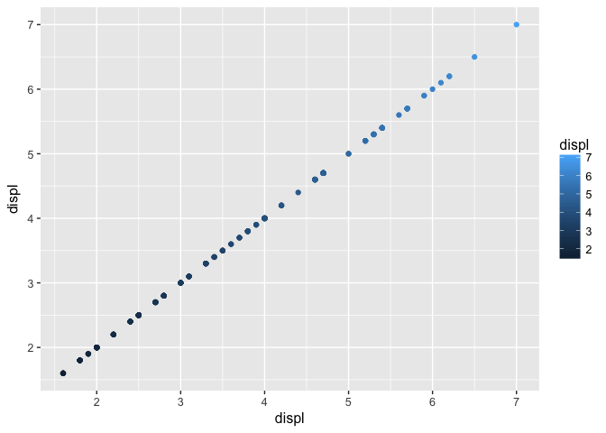

```r
ggplot(data = mpg) +
  geom_point(mapping = aes(x = displ, y = displ, color = displ))
```

```r
#it will become a great correlation line
```

## What does the stroke aesthetic do? What shapes does it work with? (Hint: use ?geom_point)

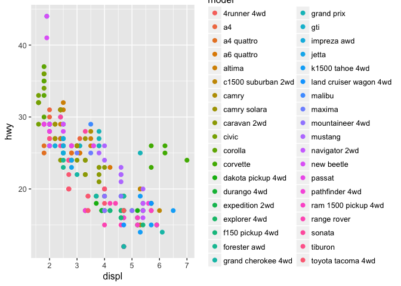

```r
ggplot(data = mpg) +
  geom_point(mapping = aes(x = displ, y = hwy,color = model), stroke = 1)
```

```r
?geom_point
#it can be used to change the size of the points in the plot
```

## What happens if you map an aesthetic to something other than a variable name, like aes(colour = displ < 5)?

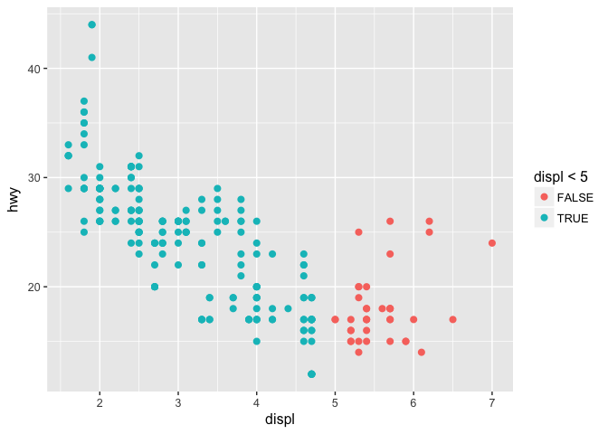

```r
ggplot(data = mpg) +
  geom_point(mapping = aes(x = displ, y = hwy,color = displ < 5), stroke = 1)
```

# practise on ‘Facets’ part. One way to add additional variables is with aesthetics, particularly useful for categorical variables.

## facet_wrap, to facet your plot by a single variable. The variable that you pass to facet_wrap() should be discrete.

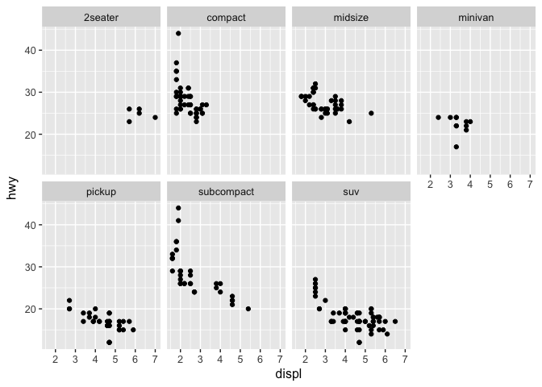

```r
ggplot(data = mpg) +
  geom_point(mapping = aes(x = displ, y = hwy)) +
  facet_wrap(~ class, nrow = 2)
```

## facet_grid, to facet your plot on the combination of two variables, or one variable

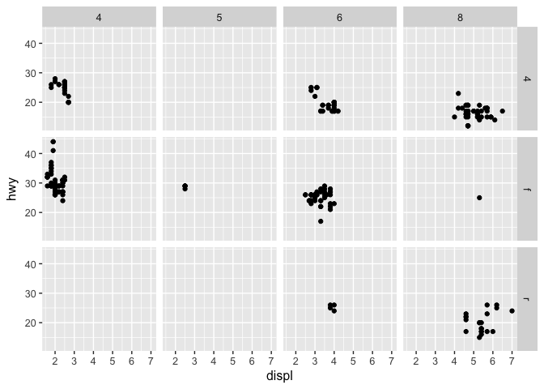

```r
ggplot(data = mpg) +
  geom_point(mapping = aes(x = displ, y = hwy)) +
  facet_grid(drv ~ cyl)
```

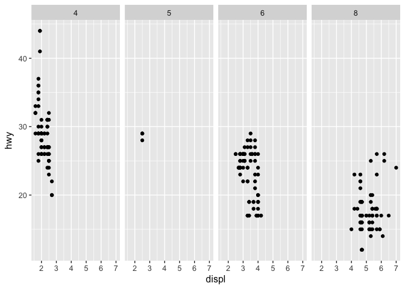

```r
ggplot(data = mpg) +
  geom_point(mapping = aes(x = displ, y = hwy)) +
  facet_grid(.~ cyl)
```

# 3.5.1 Excercises

## 1.What happens if you facet on a continuous variable?

### facet_wrap

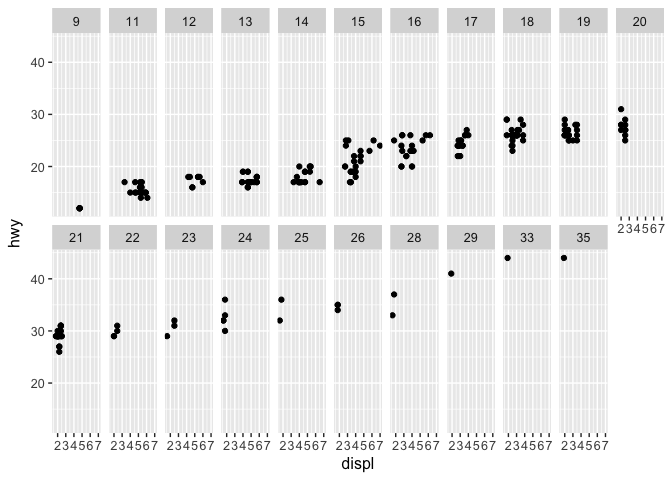

```r
ggplot(data = mpg) +
  geom_point(mapping = aes(x = displ, y = hwy)) +
  facet_wrap(~ cty, nrow = 2)
```

### try to facet_grid the continuous variable

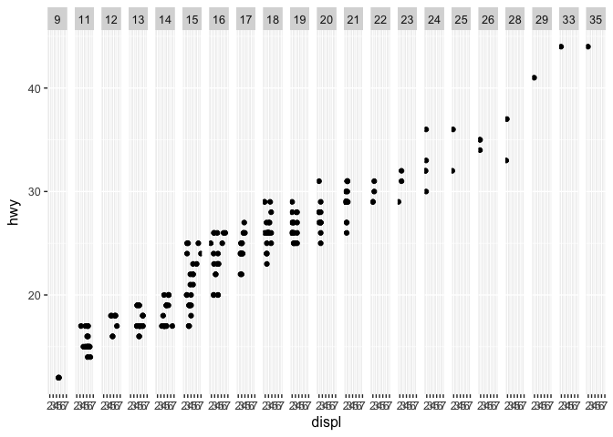

```r
ggplot(data = mpg) +
  geom_point(mapping = aes(x = displ, y = hwy)) +
  facet_grid(~ cty)
```

## 2.What do the empty cells in plot with facet_grid(drv ~ cyl) mean? How do they relate to this plot?

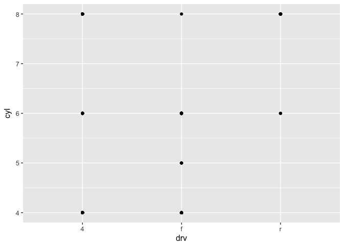

```r
ggplot(data = mpg) +
  geom_point(mapping = aes(x = drv, y = cyl))
```

```r
#there are no points when drv equals to "4" and cyl equals to "5"
```

## 3.What plots does the following code make? What does . do?

### facet only in y-axies

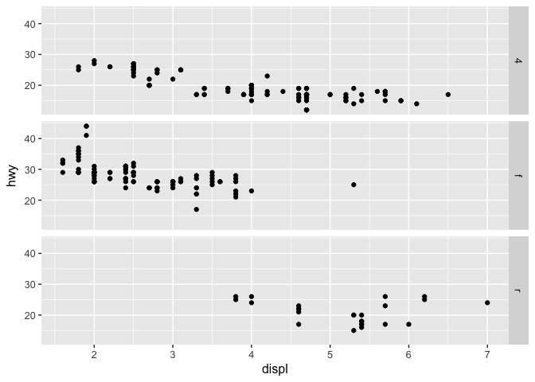

```r
ggplot(data = mpg) +
  geom_point(mapping = aes(x = displ, y = hwy)) +
  facet_grid(drv ~ .)
```

```r
?facet_grid
```

### facet only in x-axies

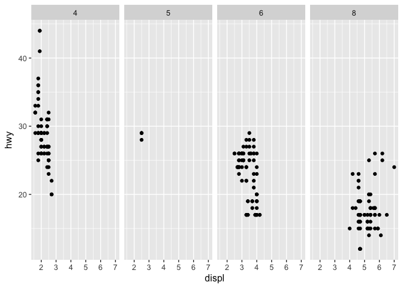

```r
ggplot(data = mpg) +
  geom_point(mapping = aes(x = displ, y = hwy)) +
  facet_grid(. ~ cyl)
```